# metacoder_exampleAnalysis

Xin (David) Zhao

2023-05-02

## Example analysis

This R Markdown file demonstrate basic workflow to plot the heat tree using `metacoder` package.

Develop the following R scripts by following the instruction step by step in the metacoder [website](https://grunwaldlab.github.io/metacoder_documentation/example.html)

### Reading data

```r
# install.packages("metacoder")
library(metacoder)
library(taxa)
```

```r
# Abundance matrix included in metacoder package
head(hmp_otus)
```

```
## # A tibble: 6 × 52
##   otu_id     lineage `700035949` `700097855` `700100489` `700111314` `700033744`
##   <chr>      <chr>         <int>       <int>       <int>       <int>       <int>
## 1 OTU_97.44… r__Roo…           0           2           1           0           0
## 2 OTU_97.45… r__Roo…           0           0           0           0           0
## 3 OTU_97.43… r__Roo…           0           1           0           0           0
## 4 OTU_97.43… r__Roo…           8          36          10           5          66
## 5 OTU_97.43… r__Roo…           3          25           0           0           0
## 6 OTU_97.44… r__Roo…          42         277          16          22          85
## # ℹ 45 more variables: `700109581` <int>, `700111044` <int>, `700101365` <int>,
## #   `700100431` <int>, `700016050` <int>, `700032425` <int>, `700024855` <int>,
## #   `700103488` <int>, `700096869` <int>, `700107379` <int>, `700096422` <int>,
## #   `700102417` <int>, `700114168` <int>, `700037540` <int>, `700106397` <int>,
## #   `700113498` <int>, `700033743` <int>, `700105205` <int>, `700024238` <int>,
## #   `700034183` <int>, `700038390` <int>, `700015973` <int>, `700038124` <int>,
## #   `700107206` <int>, `700037403` <int>, `700098429` <int>, …
```

In `hmp_otus`, columns are samples and rows are OTUs.

```r
# Load sample data table
head(hmp_samples)
```

```
## # A tibble: 6 × 3
##   sample_id sex    body_site
##   <chr>     <chr>  <chr>
## 1 700035949 female Nose
## 2 700097855 female Nose
## 3 700100489 female Nose
## 4 700111314 female Nose
## 5 700033744 female Nose
## 6 700109581 male   Nose
```

In `hmp_samples`, columns are clinical variables and rows are samples.

Process the abundance matrix and parse the taxonomic information in the mean time.

```r
obj <- metacoder::parse_tax_data(hmp_otus,
                                 class_cols = "lineage", # The column contains taxonomic information
                                 class_sep = ";", # The character separating taxa in the lineage
                                 class_regex = "^(.+)_(.+)$", # Regex identifying where the string for each taxon is
                                 class_key = c(tax_rank = "info", # A key describing each regex capture group
                                               tax_name = "taxon_name"))
```

```r
# View the obj, a taxmap object
print(obj)
```

```
## <Taxmap>
##   174 taxa: ab. Root, ac. Proteobacteria ... gs. Clostridium
##   174 edges: NA->ab, ab->ac, ab->ad ... cm->gq, cf->gr, cw->gs
##   2 data sets:
##     tax_data:
##       # A tibble: 1,000 × 53
##         taxon_id otu_id    lineage `700035949` `700097855` `700100489`
##         <chr>    <chr>     <chr>         <int>       <int>       <int>
##       1 dm       OTU_97.4… r__Roo…           0           2           1
##       2 dn       OTU_97.4… r__Roo…           0           0           0
##       3 do       OTU_97.4… r__Roo…           0           1           0
##       # ℹ 997 more rows
##       # ℹ 47 more variables: `700111314` <int>, `700033744` <int>,
##       #   `700109581` <int>, `700111044` <int>, `700101365` <int>,
##       #   `700100431` <int>, `700016050` <int>, `700032425` <int>,
##       #   `700024855` <int>, `700103488` <int>, …
##     class_data:
##       # A tibble: 5,922 × 5
##         taxon_id input_index tax_rank tax_name            regex_match
##         <chr>          <int> <chr>    <chr>               <chr>
##       1 ab                 1 r_       Root                r__Root
##       2 ac                 1 p_       Proteobacteria      p__Proteoba…
##       3 aj                 1 c_       Gammaproteobacteria c__Gammapro…
##       # ℹ 5,919 more rows
##   0 functions:
```

### Abundance matrix manipulation

#### Remove low-abundance counts

The low-abundance sequences might be the results of sequencing error, so typically we remove any counts/ OTUs with less than some number of reads. In this example analysis, set all counts with less than 5 reads to zero, overwriting the original table.

```r
obj$data$tax_data <- metacoder::zero_low_counts(obj,
                                                data = "tax_data",
                                                min_count = 5)
```

```
## No `cols` specified, so using all numeric columns:
##    700035949, 700097855, 700100489 ... 700102367, 700101358
```

```
## Zeroing 4325 of 50000 counts less than 5.
```

Check OTUs that no longer contain any observations after setting low-abundance to zero.

```r
no_reads <- base::rowSums(obj$data$tax_data[, hmp_samples$sample_id]) == 0

# Print 211 OTUs that has zero reads
sum(no_reads)
```

```
## [1] 211
```

Remove 211 OTUs and their associated taxa with `filter_obs` from `taxa` package.

```r
obj <- metacoder::filter_obs(obj,
                             data = "tax_data",
                             !no_reads,
                             drop_taxa = TRUE)

# print(obj)
```

#### Accounting for un-even sampling

In practice, some samples may have more reads than others due to imperfect sequencing technologies. Typically, people work with rarefied counts or proportions to try to avoid the possibility fo sampling depth biasing the results.

Use the function `calc_obs_props` to divide each sample’s counts by the total number of counts observed for each sample, resulting in a proportion.

```r
obj$data$tax_data <- metacoder::calc_obs_props(obj, "tax_data")
```

```
## No `cols` specified, so using all numeric columns:
##    700035949, 700097855, 700100489 ... 700102367, 700101358
```

```
## Calculating proportions from counts for 50 columns for 789 observations.
```

#### Get per-taxon information

To get information on the taxa, we sum the abundance per-taxon and add the results to the `taxmap` object in a new table.

```r
# Sum observation values for each taxon
obj$data$tax_abund <- metacoder::calc_taxon_abund(obj, # taxmap object
                                                  "tax_data", # The name of a table in obj$data
                                                  cols = hmp_samples$sample_id) # The columns in data to use
```

```
## Summing per-taxon counts from 50 columns for 155 taxa
```

Calculate the number of samples that have reads for each taxon.

```r
# Count the number of samples
obj$data$tax_occ <- metacoder::calc_n_samples(obj, # A taxmp object
                                              "tax_abund",
                                              groups = hmp_samples$body_site, # Group columns per treatment/group
                                              cols = hmp_samples$sample_id)
```

```
## Calculating number of samples with a value greater than 0 for 50 columns in 5 groups for 155 observations
```

```r
print(obj$data$tax_occ)
```

```
## # A tibble: 155 × 6
##    taxon_id  Nose Saliva  Skin Stool Throat
##    <chr>    <int>  <int> <int> <int>  <int>
##  1 ab          10     10    10    10     10
##  2 ac           8     10     9     2     10
##  3 ad           5     10     8    10     10
##  4 ae          10     10    10     1      9
##  5 af          10     10    10    10     10
##  6 ag           1     10     2     0      9
##  7 ah           0      0     2     3      0
##  8 aj           6     10     9     0     10
##  9 ak           2     10     0     0      3
## 10 al           4     10     8    10     10
## # ℹ 145 more rows
```

### Plot taxonomic tree (also known as heat tree)

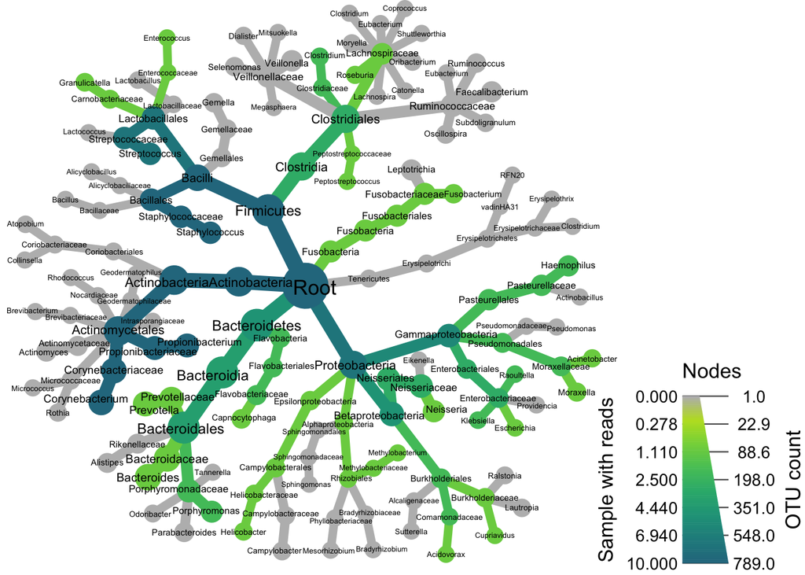

```r
set.seed(1) # This makes the plot appear the same every time it is generated

metacoder::heat_tree(obj, # A taxmap object
                     node_label = taxon_names,
                     node_size = n_obs,
                     node_color = Nose, # Non-standard evaluation (NSE)
                     node_size_axis_label = "OTU count",
                     node_color_axis_label = "Sample with reads",
                     layout = "davidson-harel", # The primary layout algorithm
                     initial_layout = "reingold-tilford") # The layout algorithm that initializes node locations
```

#### Compare two treatments/ groups

```r
obj$data$diff_table <- metacoder::compare_groups(obj,
                                                 data = "tax_abund",
                                                 cols = hmp_samples$sample_id, # What columns of samples data to use
                                                 groups = hmp_samples$sex) # What category each sample is assigned to

print(obj$data$diff_table)
```

```
## # A tibble: 155 × 7
##    taxon_id treatment_1 treatment_2 log2_median_ratio median_diff mean_diff
##    <chr>    <chr>       <chr>                   <dbl>       <dbl>     <dbl>
##  1 ab       female      male                    0          0        0
##  2 ac       female      male                    0.380      0.0229   0.0379
##  3 ad       female      male                   -0.434     -0.0449  -0.0199
##  4 ae       female      male                   -1.68      -0.0475  -0.0753
##  5 af       female      male                    0.649      0.116    0.0614
##  6 ag       female      male                    0          0       -0.00275
##  7 ah       female      male                    0          0       -0.00140
##  8 aj       female      male                    1.24       0.0162  -0.0129
##  9 ak       female      male                    0          0        0.00121
## 10 al       female      male                   -0.542     -0.0541  -0.0211
## # ℹ 145 more rows
## # ℹ 1 more variable: wilcox_p_value <dbl>
```

Correct for multiple comparisons.

```r
# FDR method
obj$data$diff_table$wilcox_p_value <- p.adjust(obj$data$diff_table$wilcox_p_value,
                                               method = "fdr")

# View the distribution of p-values
range(obj$data$diff_table$wilcox_p_value, finite = TRUE)
```

```
## [1] 0.8029954 1.0000000
```

There is no significant difference.

For each taxon, a Wilcoxon Rank Sum test was used to test for difference between the median abundances of samples in each treatment. We use this information to create what we call a differential heat tree, which indicates which taxa are more abundant in each treatment.

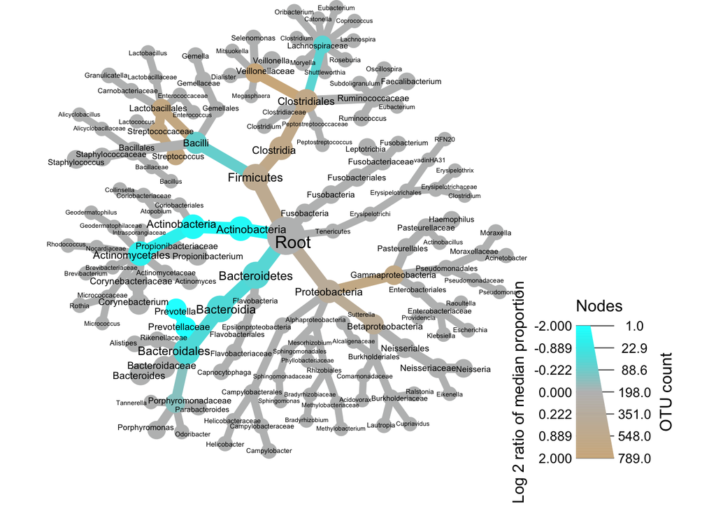

```r
set.seed(999)
metacoder::heat_tree(obj,
                     node_label = taxon_names,
                     node_size = n_obs, # n_obs in a function that calculates the number of OTUs per taxon
                     node_color = log2_median_ratio, # A column from 'obj$data$diff_table'
                     node_color_interval = c(-2, 2), # The range of 'log2_median_ratio' to display
                     node_color_range = c("cyan", "gray", "tan"), # The color palette used
                     node_size_axis_label = "OTU count",
                     node_color_axis_label = "Log 2 ratio of median proportion",
                     layout = "davidson-harel", # The primary layout algorithm
                     initial_layout = "reingold-tilford") # The layout algorithm
```

#### Compare multiple treatments/ groups

To compare more than two groups, we can make a matrix of heat trees, one for each pairwise comparison of treatments

```r
obj$data$diff_table <- metacoder::compare_groups(obj,
                                                 data = "tax_abund",
                                                 cols = hmp_samples$sample_id,
                                                 groups = hmp_samples$body_site) # What category each sample is assigned to


print(obj$data$diff_table)
```

```
## # A tibble: 1,550 × 7
##    taxon_id treatment_1 treatment_2 log2_median_ratio median_diff mean_diff
##    <chr>    <chr>       <chr>                   <dbl>       <dbl>     <dbl>
##  1 ab       Nose        Saliva                   0         0         0
##  2 ac       Nose        Saliva                  -2.62     -0.167    -0.128
##  3 ad       Nose        Saliva                  -7.68     -0.274    -0.265
##  4 ae       Nose        Saliva                   5.36      0.616     0.595
##  5 af       Nose        Saliva                  -1.23     -0.260    -0.159
##  6 ag       Nose        Saliva                -Inf        -0.0228   -0.0436
##  7 ah       Nose        Saliva                   0         0         0
##  8 aj       Nose        Saliva                  -3.83     -0.103    -0.0803
##  9 ak       Nose        Saliva                -Inf        -0.0174   -0.0174
## 10 al       Nose        Saliva                -Inf        -0.258    -0.248
## # ℹ 1,540 more rows
## # ℹ 1 more variable: wilcox_p_value <dbl>
```

A special function `heat_tree_matrix` to plot this type of data

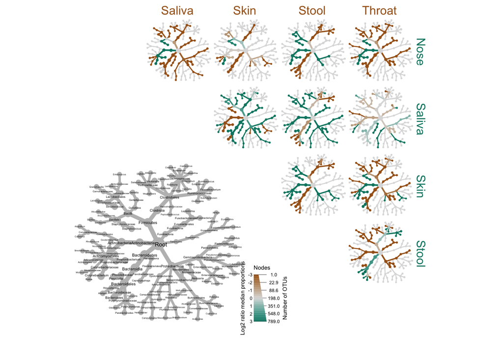

```r
set.seed(1)

metacoder::heat_tree_matrix(obj,
                            data = "diff_table",
                            node_size = n_obs,
                            node_label = taxon_names,
                            node_color = log2_median_ratio,
                            node_color_range = diverging_palette(),
                            node_color_trans = "linear",
                            node_color_interval = c(-3, 3),
                            edge_color_interval = c(-3, 3),
                            node_size_axis_label = "Number of OTUs",
                            node_color_axis_label = "Log2 ratio median proportions",
                            layout = "davidson-harel",
                            initial_layout = "reingold-tilford",
                            output_file = "./Phylogeny_output.pdf")
```

The grey tree on the lower left functions as a key for the unlabeled trees.